# Univariate Plots Section

# Multivariate Plots Section

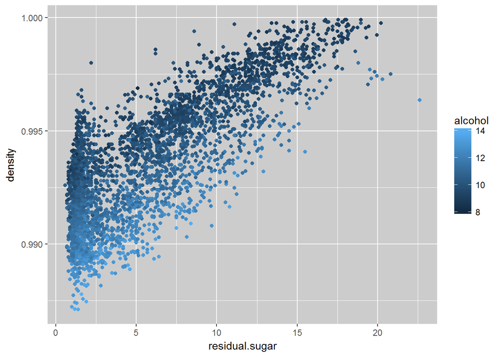

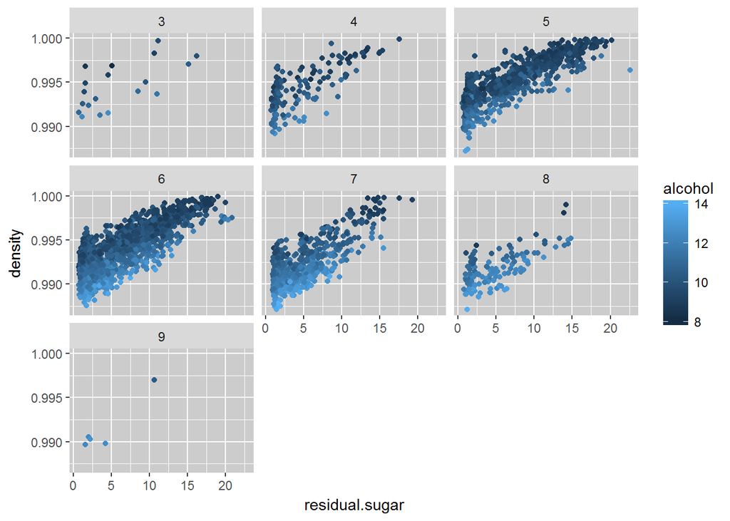

Here’s a better look at how density depends on both alcohol and sugar. We see that the alcohol contributes to the density by being on the lower portion of the scatterplot, but the trend is governed by the sugar content. In the facet plot, each of the quality facets isolates a region on the density vs. sugar plot where the alcohol content is (generally) high, while the sugar and density levels are low. Again, this demonstrates that the high-quality wines tend to have low densities, which depends on alcohol and sugar content. Here’s another view of the same insight, this time using sugar as the color scale.

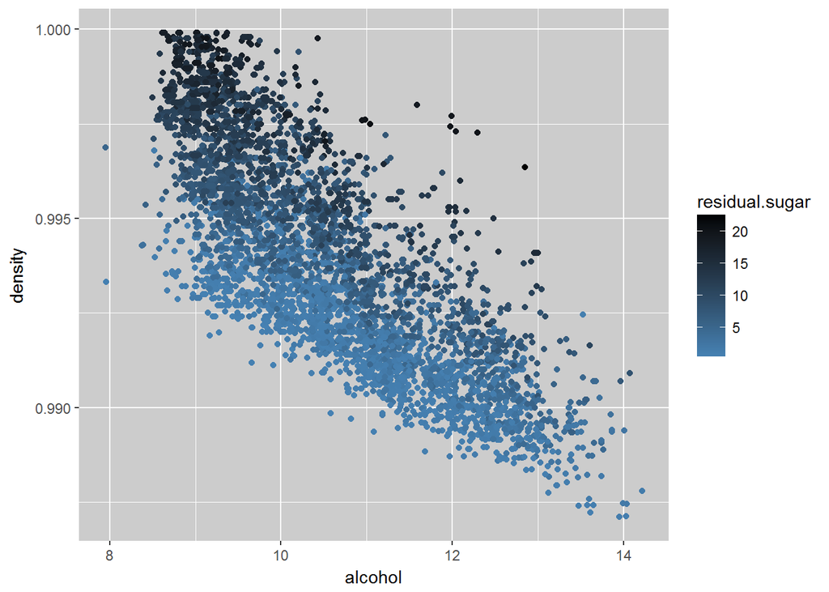

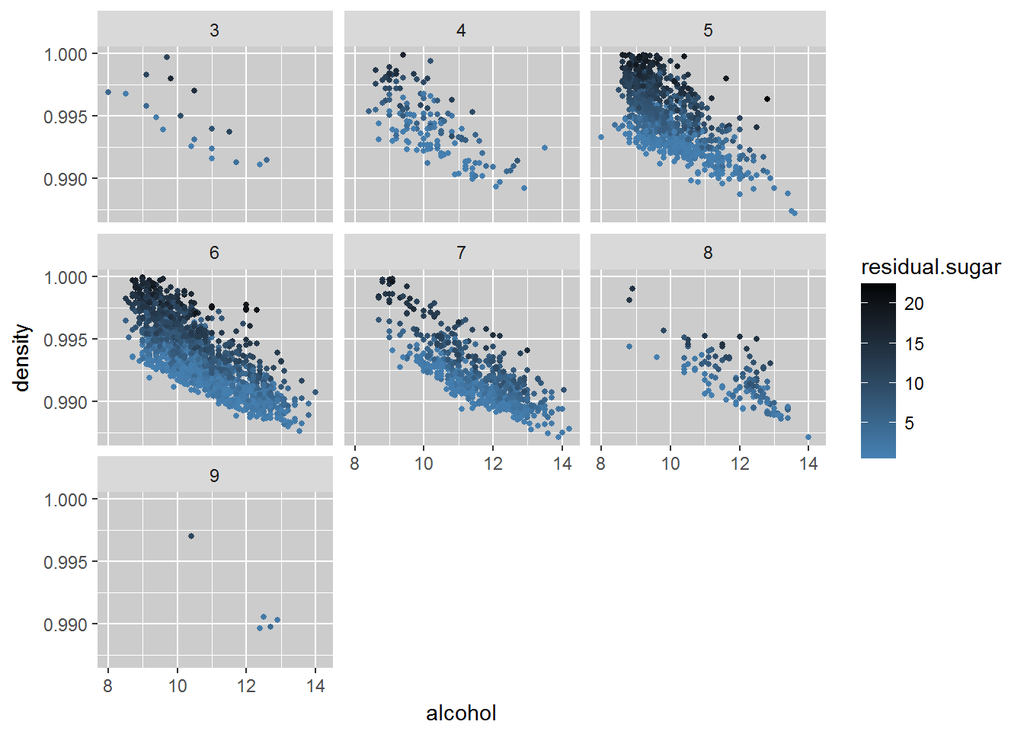

The density vs. alcohol plot forms the shape of a knife, whose lower edge corresponds to a region with low sugar content. As the quality increases, the edge and tip of this knife is isolated.

Let’s form a simple linear model where density depends on a linear combination of alcohol percentage, residual sugar content, and total sulfur dioxide:

```
##
## Calls:
## density_model: lm(formula = density ~ alcohol + residual.sugar, data = wines)
## density_model2: lm(formula = density ~ alcohol + residual.sugar + total.sulfur.dioxide,
##     data = wines)
## density_model3: lm(formula = density ~ alcohol + residual.sugar + total.sulfur.dioxide +
##     free.sulfur.dioxide + fixed.acidity + chlorides, data = wines)
## density_model4: lm(formula = density ~ alcohol + residual.sugar + total.sulfur.dioxide +
##     free.sulfur.dioxide + fixed.acidity + chlorides + pH, data = wines)
##
## =======================================================================================
##                         density_model  density_model2  density_model3  density_model4
## ---------------------------------------------------------------------------------------
##   (Intercept)             1.005***        1.003***        0.999***        0.986***
##                          (0.000)         (0.000)         (0.000)         (0.000)
##   alcohol                -0.001***       -0.001***       -0.001***       -0.001***
##                          (0.000)         (0.000)         (0.000)         (0.000)
##   residual.sugar          0.000***        0.000***        0.000***        0.000***
##                          (0.000)         (0.000)         (0.000)         (0.000)
##   total.sulfur.dioxide                    0.000***        0.000***        0.000***
##                                          (0.000)         (0.000)         (0.000)
##   free.sulfur.dioxide                                    -0.000***       -0.000***
##                                                          (0.000)         (0.000)
##   fixed.acidity                                           0.001***        0.001***
##                                                          (0.000)         (0.000)
##   chlorides                                               0.003***        0.005***
##                                                          (0.001)         (0.000)
##   pH                                                                      0.004***
##                                                                          (0.000)
## ---------------------------------------------------------------------------------------
##   R-squared                   0.907           0.911           0.936           0.961
##   adj. R-squared              0.907           0.911           0.936           0.961
##   sigma                       0.001           0.001           0.001           0.001
##   F                       23791.076       16738.603       11882.257       17368.912
##   p                           0.000           0.000           0.000           0.000
##   Log-likelihood          27328.019       27448.397       28242.961       29484.775
##   Deviance                    0.004           0.004           0.003           0.002
##   AIC                    -54648.037      -54886.794      -56469.921      -58951.550
##   BIC                    -54622.051      -54854.311      -56417.949      -58893.080
##   N                        4898            4898            4898            4898
## =======================================================================================
```

Here are the density plots with diverging color palettes encoding wine quality.

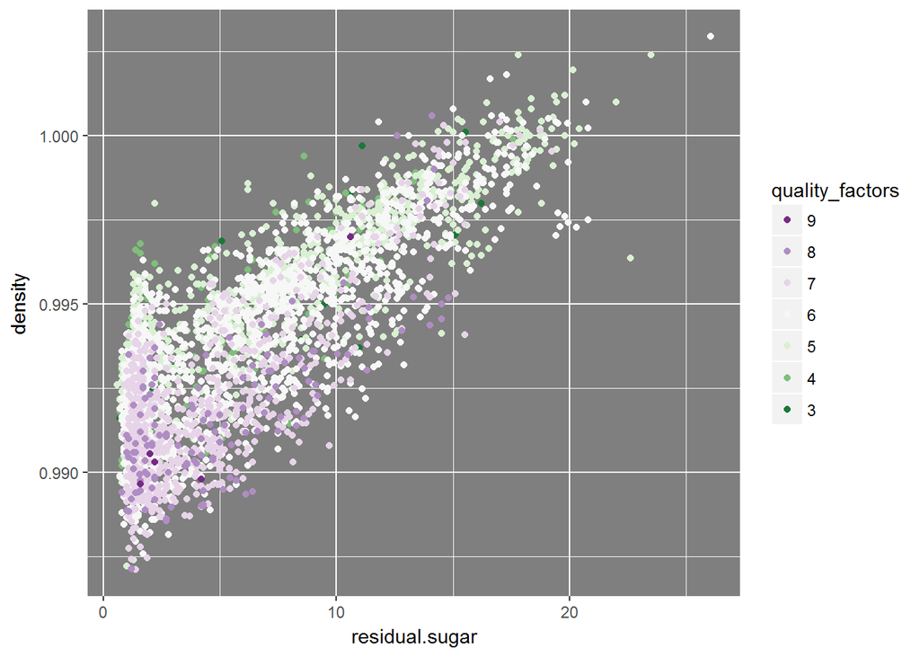

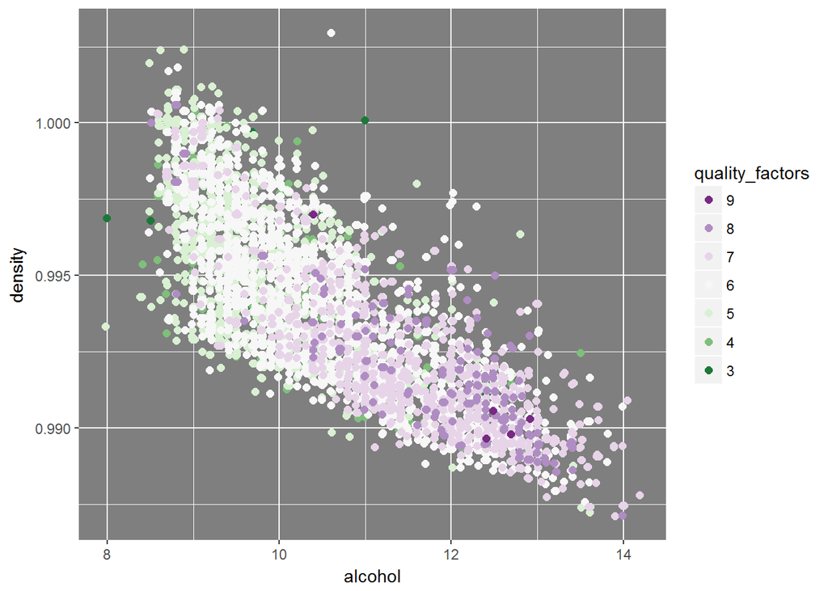

# Multivariate Analysis

### Talk about some of the relationships you observed in this part of the investigation. Were there features that strengthened each other in terms of looking at your feature(s) of interest?

Both `alcohol` and `residual.sugar` contribute to the density of wines. As we facet either a `density` vs. `alcohol` or `density` vs. `residual.sugar` plot by `quality_factors`, we notice that for a higher rated wine, the density and sugar levels tend to be lower, and the alcohol levels are higher. However, there are plenty of high alcohol, low density wines that are lower rated as well.

### Were there any interesting or surprising interactions between features?

Although the pH has a linear relationship with density, it is mostly flat, meaning that the pH may vary without the density changing for a wide range of pH values. Despite this, variability of the pH contributes more to the variability of the density than chlorides or the total sulfur dioxide content, despite their stronger correlation with the density.

### OPTIONAL: Did you create any models with your dataset? Discuss the strengths and limitations of your model.

Yes, I created a linear model of the density of wines, considering their alcohol and sugar content. These two variables alone account for over 90% of the variability of density. Adding other variables like `total.sulfur.dioxide`, `free.sulfur.dioxide`, `fixed.acidity` and `chlorides` only adds a couple of percentage points to the R<sup>2</sup> score.

Unfortunately, this model is insufficient for predicting the quality rating of a given wine, because density (and all the factors that influence it) is not a good indicator for determining low quality wines.

# Final Plots and Summary

### Plot One

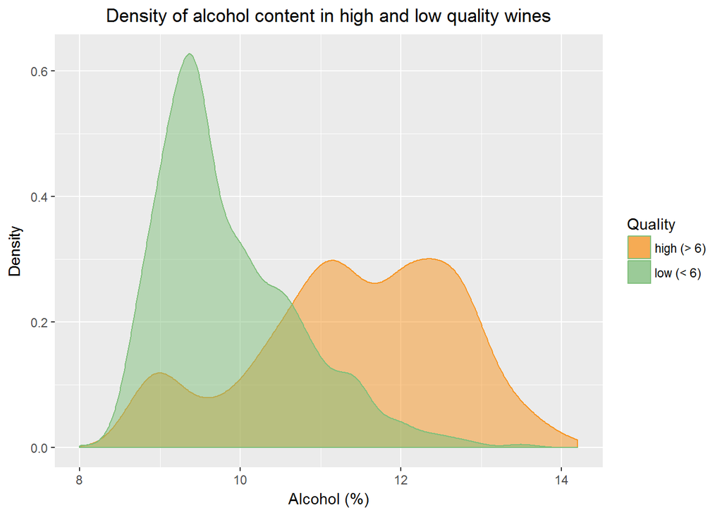

### Description One

This density plot of alcohol distributions for low and high quality wines shows that highly rated wines tend to have more alcohol than low-rated wines.

### Plot Two

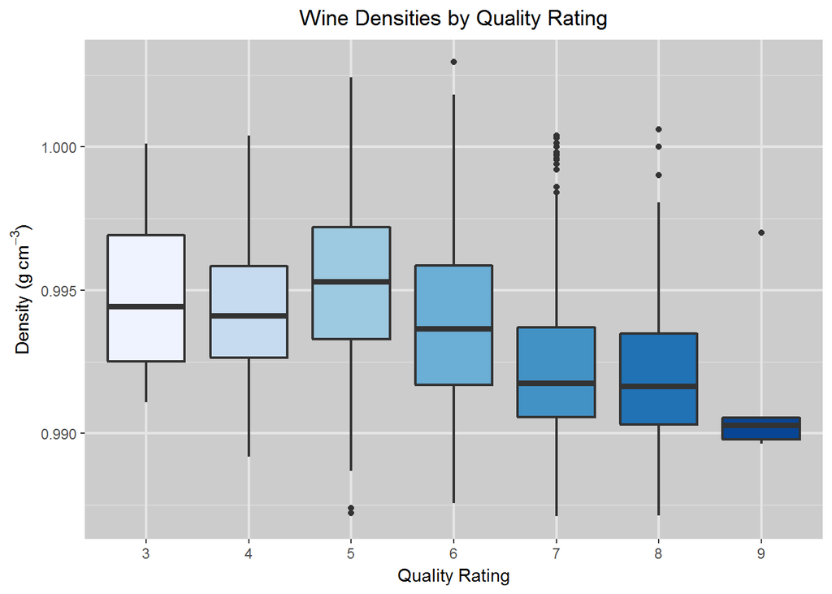

### Description Two

The highest rated wines (7-9) have the lowest densities. The spread of density data is wide for middle-rated wines (5-6), with large outliers (not pictured) for 6-rated wines due to abnormally high sugar content.

### Plot Three

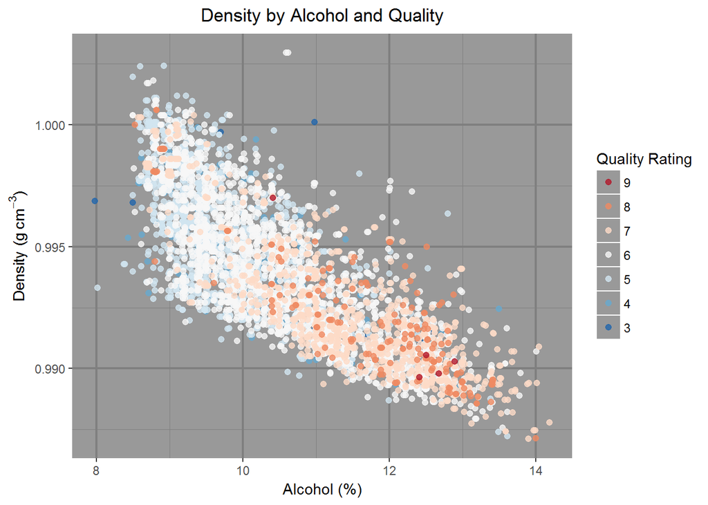

### Description Three

Each rating forms a layer in the scatterplot, with the highest quality wines (in red) forming the topmost layers. The highest quality wines tend to have low densities and high alcohol content compared to the lowest-rated wines (in blue).

# Reflection

I explored a dataset of around 5000 white wines to help answer the question: “What chemical and physical properties of white wines determine their quality?” There was a total of 12 features to explore, including the quality rating. I first examined each of them individually, then pursued some further questions generated by this initial examination, eventually observing interactions over multiple variables.

At first I looked at distributions of certain physical and chemical quantities like density, pH, sugar content and alcohol content. Then I found that if I were to examine distributions by rating, I could see what made high quality wines different from low quality wines. I discovered such differences with the `density` and `alcohol` variables most notably. All the while I checked inter-feature correlations as a guide as to which features contribute to affecting these variables the most. Observing the `density` distribution as a function of quality rating led me to discover three major outliers with very high densities. This tipped me off to surmise that the sugar content (which also had a few major outliers) has a large impact on density, which I confirmed by making a density vs. sugar plot and noticing a strong linear trend. Alcohol content should also affect density, so I examined their relationship as well. One surprising yet unexplained observation I found is that the pH also affects density but only in terms of its variability, because adding pH into the density model improved the R<sup>2</sup> score more than any other quantity except sugar and alcohol.

I have yet to make any accurate models for the quality of wines based on factors like `density` or `alcohol`. While high quality wines have low densities, low sugar, and a high alcohol percentage, there are plenty of middling and low quality wines with those attributes as well. It was difficult for me to find anything that distinguishes a low-rated (3-4) wine from a middle-rated wine (5-6). In future work, I would try to incorporate more of the other seemingly less correlated features into the analysis, since I discovered that high quality wines tend to have low quantities of chlorides and sulfur dioxide, while low quality wines have high fixed acidities. How these features affect wine quality are more subtle and would probably require a bit more knowledge as to how they change the taste, color and smell of wines, which are major factors in judging wine quality.